# Лабораторная работа №8: Диаграммы и чертежи как код

Дисциплина: Компьютерный практикум по научному письму

ДАБВАН ЛУАИ МОХАММЕД АЛИ, НФИмд-01-24, 1032249837

Российский университет дружбы народов, Москва, Россия

20 декабря 2025

## Преподаватель

**ФИО:** Кулябов Дмитрий Сергеевич **Должность:** Профессор кафедры прикладной информатики и теории вероятностей РУДН **Дисциплина:** Компьютерный практикум по научному письму

## Информация о докладчике

Дабвван Луаи Мохаммед Али Студент 2 курса Направление: 02.04.02 Фундаментальная информатика и информационные технологии (магистратура) Российский университет дружбы народов

# Вводная часть

### Актуальность темы:

В этом исследовании рассматривается создание диаграмм и графиков с помощью TikZ в LaTeX. Мы используем TikZ для рисования фракталов и математических графиков, таких как Sierpiński carpet. Этот инструмент используется для создания научных и математических визуализаций с высокой точностью и гибкостью.

### Объект и предмет исследования:

- бОбъект исследования: создание фракталов и графиков с помощью TikZ в LaTeX.
- Предмет исследования: методы и способы рисования фракталов (например, Серпинский карпет) и математических графиков (например, графики функций) с использованием TikZ.

## Вводная часть

### Научная новизна:

В данном исследовании используется новый подход для генерации графиков и фракталов. Использование TikZ в LaTeX позволяет интегрировать математические графики и фракталы в научные документы, что делает их более точными и интерактивными.

### Практическая значимость:

Практическая значимость работы заключается в том, что TikZ в LaTeX позволяет ученым и исследователям быстро создавать визуализации для научных работ. Это значительно ускоряет процесс создания научных презентаций и помогает представить сложные данные.

# Цель работы , задачи и гипотеза

## Цель работы:

изучить возможности использования TikZ в LaTeX для создания фракталов и математических графиков в научных документах.

## Гипотеза:

Гипотеза исследования заключается в том, что TikZ в LaTeX является более эффективным инструментом для создания фракталов и графиков по сравнению с другими инструментами, такими как PowerPoint.

## Материалы и методы

В этом исследовании использовались экспериментальные методы для изучения TikZ и его применения в создании фракталов и графиков.

# Содержание исследования

## 1.Предлагаемое решение задач исследования с обоснованием

Решение заключается в использовании TikZ в LaTeX для создания фракталов и графиков. Этот инструмент позволяет создать высококачественные графики с интеграцией математических формул.

# 2.Основные этапы работы

## Упражнение 1

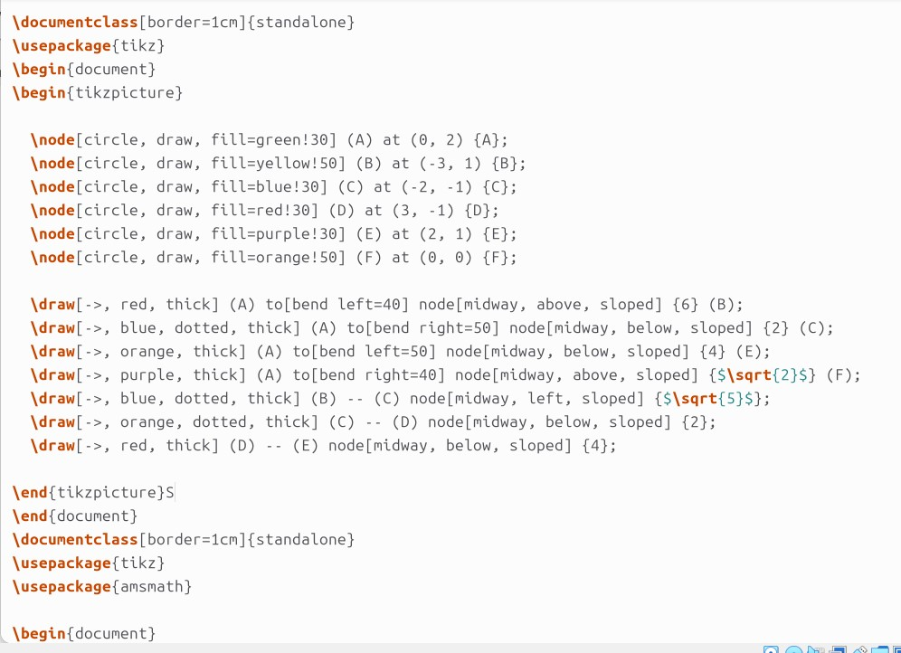

## Результат:

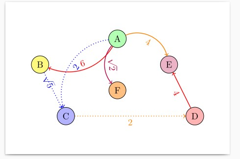

## Упражнение 2

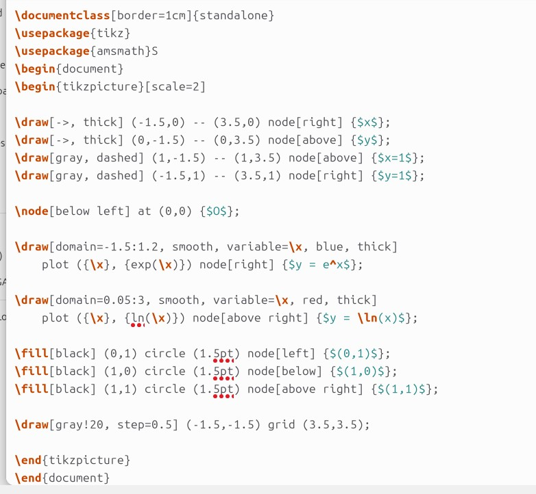

## Результат:

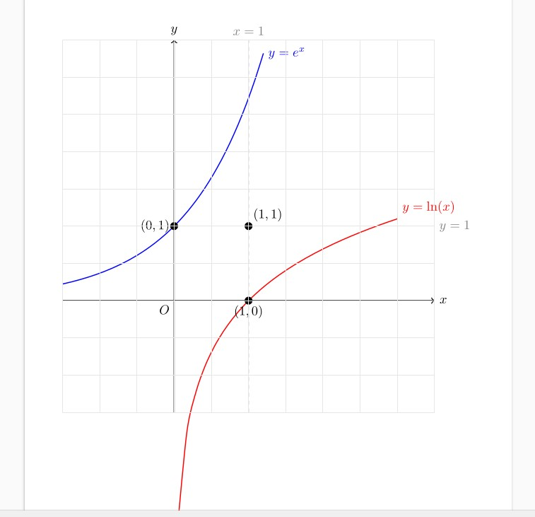

## Упражнение 3 .

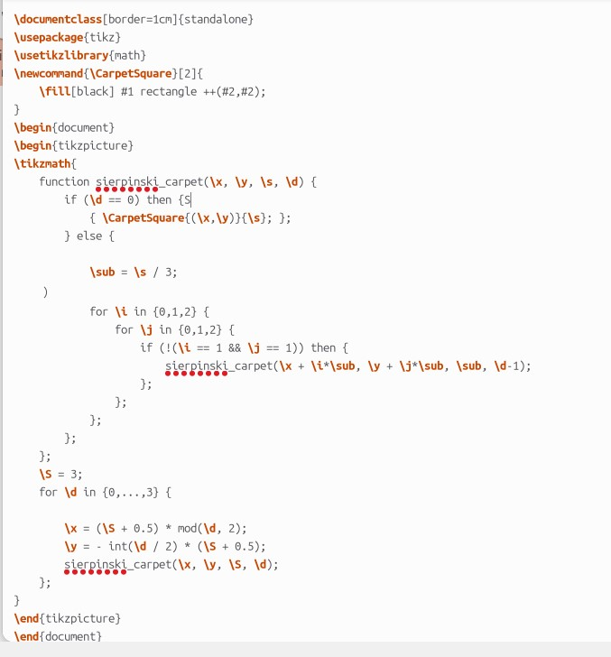

## Результат:

[figure not shown]

# Анализ и практическая значимость достигнутых результатов

## Практическая значимость работы заключается в том, что освоенные методы позволяют:

Практическая значимость заключается в том, что TikZ позволяет создавать научные презентации с высокой точностью. Это позволяет ученым и исследователям быстро создавать визуализации и представления данных для научных конференций и лекций.

# Выводы по проделанной работе

Использование TikZ в LaTeX для создания фракталов и математических графиков доказало свою эффективность и точность. Это решение представляет собой перспективный инструмент для подготовки научных материалов, и его использование продолжает расти среди исследователей и студентов.